# **Problem Statement**

The objective of this case study is to develop a predictive model for LoanTap, an online platform specializing in customized loan products for millennials. The focus is on the underwriting process for Personal Loans. Given a set of attributes for an individual, the goal is to determine whether a credit line should be extended and, if so, to provide recommendations on the repayment terms. The model should accurately predict the likelihood of loan repayment versus default, helping LoanTap make informed lending decisions and minimize the risk of non-performing assets (NPAs).

# Imports and Dataset

## Imports

**Imports for EDA**

```python
import numpy as np
import pandas as pd
import matplotlib.pyplot as plt
import seaborn as sns
```

**Encoding Imports**

```python
from sklearn.impute import SimpleImputer
```

**Imports for Logistic Regression**

```python
from sklearn.model_selection import train_test_split
from sklearn.preprocessing import MinMaxScaler
from sklearn.linear_model import LogisticRegression
from sklearn import metrics
```

**VIF import**

```python
from statsmodels.stats.outliers_influence import variance_inflation_factor
```

## Dataset

```python
df = pd.read_csv("loan_tap.csv")
df.head()
```

|  | loan_amnt | term | int_rate | installment | grade | sub_grade | emp_title | emp_length | home_ownership | annual_inc | ... | open_acc | pub_rec | revol_bal | revol_util | total_acc | initial_list_status | application_type | mort_acc | pub_rec_bankruptcies | address |
| --- | --- | --- | --- | --- | --- | --- | --- | --- | --- | --- | --- | --- | --- | --- | --- | --- | --- | --- | --- | --- | --- |
| 0 | 10000.0 | 36 months | 11.44 | 329.48 | B | B4 | Marketing | 10+ years | RENT | 117000.0 | ... | 16.0 | 0.0 | 36369.0 | 41.8 | 25.0 | w | INDIVIDUAL | 0.0 | 0.0 | 0174 Michelle Gateway\r\nMendozaberg, OK 22690 |
| 1 | 8000.0 | 36 months | 11.99 | 265.68 | B | B5 | Credit analyst | 4 years | MORTGAGE | 65000.0 | ... | 17.0 | 0.0 | 20131.0 | 53.3 | 27.0 | f | INDIVIDUAL | 3.0 | 0.0 | 1076 Carney Fort Apt. 347\r\nLoganmouth, SD 05113 |
| 2 | 15600.0 | 36 months | 10.49 | 506.97 | B | B3 | Statistician | < 1 year | RENT | 43057.0 | ... | 13.0 | 0.0 | 11987.0 | 92.2 | 26.0 | f | INDIVIDUAL | 0.0 | 0.0 | 87025 Mark Dale Apt. 269\r\nNew Sabrina, WV 05113 |
| 3 | 7200.0 | 36 months | 6.49 | 220.65 | A | A2 | Client Advocate | 6 years | RENT | 54000.0 | ... | 6.0 | 0.0 | 5472.0 | 21.5 | 13.0 | f | INDIVIDUAL | 0.0 | 0.0 | 823 Reid Ford\r\nDelacruzside, MA 00813 |
| 4 | 24375.0 | 60 months | 17.27 | 609.33 | C | C5 | Destiny Management Inc. | 9 years | MORTGAGE | 55000.0 | ... | 13.0 | 0.0 | 24584.0 | 69.8 | 43.0 | f | INDIVIDUAL | 1.0 | 0.0 | 679 Luna Roads\r\nGreggshire, VA 11650 |

5 rows × 27 columns

# Data Preprocessing and EDA

## Basic Checks

```python
df.shape
```

```
(396030, 27)
```

```python
df.duplicated().sum()
```

```
0
```

```python
df.info()
```

```
<class 'pandas.core.frame.DataFrame'>
RangeIndex: 396030 entries, 0 to 396029
Data columns (total 27 columns):
 #   Column                Non-Null Count   Dtype
---  ------                --------------   -----
 0   loan_amnt             396030 non-null  float64
 1   term                  396030 non-null  object
 2   int_rate              396030 non-null  float64
 3   installment           396030 non-null  float64
 4   grade                 396030 non-null  object
 5   sub_grade             396030 non-null  object
 6   emp_title             373103 non-null  object
 7   emp_length            377729 non-null  object
 8   home_ownership        396030 non-null  object
 9   annual_inc            396030 non-null  float64
```

[output cut: 19 more lines]

- Total Number of rows: 396030
- Total Number of Columns: 27
- No duplicates.
- There are some missing values.

## Missing values Treatment

```python
missing = df.isna().sum() * 100 / len(df)
missing = missing[(missing > 0)]

print('Columns with missing values')
missing
```

```
Columns with missing values
```

```
emp_title               5.789208
emp_length              4.621115
title                   0.443148
revol_util              0.069692
mort_acc                9.543469
pub_rec_bankruptcies    0.135091
dtype: float64
```

Removing rows which contains less than 3% missing values.

```python
df.dropna(subset=(missing[missing <= 3]).index, inplace=True)
```

```python
missing = df.isna().sum() * 100 / len(df)
missing = missing[(missing > 0)]

print('Columns with % missing values')
missing
```

```
Columns with % missing values
```

```
emp_title     5.761122
emp_length    4.594055
mort_acc      9.453192
dtype: float64
```

Filling emp_title missing values with 'Unknown'

```python
df['emp_title'].fillna(value= 'Unknown', inplace=True)
```

Filling emp_length missing values with most_frequent value

```python
emp_length_imputer = SimpleImputer(strategy="most_frequent")
df['emp_length'] = emp_length_imputer.fit_transform(df[['emp_length']]).flatten()
```

```python
mort_acc_imputer = SimpleImputer(strategy="median")
df['mort_acc'] = mort_acc_imputer.fit_transform(df[['mort_acc']]).flatten()
```

```python
missing = df.isna().sum() * 100 / len(df)
missing = missing[(missing > 0)]

print('Columns with % missing values')
missing
```

```
Columns with % missing values
```

```
Series([], dtype: float64)
```

**Missing values has been treated.**

## Other Columns Treatment

### Change dtype of date/time columns

```python
df['issue_d'][:5]
```

```
0    Jan-2015
1    Jan-2015
2    Jan-2015
3    Nov-2014
4    Apr-2013
Name: issue_d, dtype: object
```

```python
df['earliest_cr_line'][:5]
```

```
0    Jun-1990
1    Jul-2004
2    Aug-2007
3    Sep-2006
4    Mar-1999
Name: earliest_cr_line, dtype: object
```

```python
# Note below steps will add day in date value, so later on if we used these column, we need to take care of it (if required).

df['issue_d'] = pd.to_datetime(df['issue_d'])
df['earliest_cr_line'] = pd.to_datetime(df['earliest_cr_line'])
```

### Feature Engineering

#### **Flagging of pub_rec, mort_acc and pub_rec_bankruptcies**

```python
def pub_rec(n: float) -> int:
    return int(n != 0)

def mort_acc(n: float) -> int:
    return int(n != 0)


def pub_rec_bankruptcies(n: float) -> int:
    return int(n != 0)
```

```python
df['pub_rec'] = df['pub_rec'].apply(pub_rec)
df['mort_acc'] = df['mort_acc'].apply(mort_acc)
df['pub_rec_bankruptcies'] = df['pub_rec_bankruptcies'].apply(pub_rec_bankruptcies)
```

#### **Extracting zip_codes and states from states**

```python
# utility function to extract states
def find_state(s: str) -> str:
    ind = s.find(',')
    output = ""

    # finding abbrevation of state
    if ind != -1:
        output = s[ind+2 : ind+4]

    if output == "Bo" or output == "":
        output = "OTHER"

    return output

def find_zip_code(s: str) -> str:
    return s[-5:]
```

```python
df['state'] = df['address'].apply(find_state)
df['zip_code'] = df['address'].apply(find_zip_code)

df.drop('address', axis=1, inplace=True) # dropping address column
```

#### **Date-time components**

```python
df['issue_d_month'] = df['issue_d'].dt.month
df['issue_d_year'] = df['issue_d'].dt.year

df['earliest_cr_line_month'] = df['earliest_cr_line'].dt.month
df['earliest_cr_line_year'] = df['earliest_cr_line'].dt.year
```

```python
df.drop(['issue_d', 'earliest_cr_line'], axis=1, inplace=True) # dropping issue_d and earliest_cr_line
```

## Analysis and Visualisations

### value_counts()

```python
df['loan_status'].value_counts(normalize=True)
```

```
Fully Paid     0.80381
Charged Off    0.19619
Name: loan_status, dtype: float64
```

```python
df['home_ownership'].value_counts()
```

```
MORTGAGE    197110
RENT        158770
OWN          37443
OTHER          110
NONE            29
ANY              3
Name: home_ownership, dtype: int64
```

combining none and any to other

```python
df.loc[df['home_ownership'].isin(['NONE', 'ANY']), 'home_ownership'] = "OTHER"
df['home_ownership'].value_counts()
```

```
MORTGAGE    197110
RENT        158770
OWN          37443
OTHER          142
Name: home_ownership, dtype: int64
```

```python
df['title'].value_counts()[:20]
```

```
Debt consolidation           152392
Credit card refinancing       51476
Home improvement              15245
Other                         12910
Debt Consolidation            11584
Major purchase                 4759
Consolidation                  3840
debt consolidation             3543
Business                       2947
Debt Consolidation Loan        2859
Medical expenses               2733
Car financing                  2135
Credit Card Consolidation      1768
Vacation                       1715
Moving and relocation          1688
consolidation                  1594
Personal Loan                  1568
Consolidation Loan             1295
Home Improvement               1265
Home buying                    1183
Name: title, dtype: int64
```

- (Consolidation, consolidation), (Debt consolidation, debt consolidation) etc are repeating.
- using str.lower to remove such discrepancies

```python
df['title'] = df['title'].str.lower()
df['title'].value_counts()[:20]
```

```
debt consolidation           168000
credit card refinancing       51770
home improvement              17093
other                         12973
consolidation                  5570
major purchase                 4988
debt consolidation loan        3508
business                       3015
medical expenses               2811
credit card consolidation      2629
personal loan                  2424
car financing                  2156
credit card payoff             1904
consolidation loan             1881
vacation                       1863
credit card refinance          1832
moving and relocation          1692
consolidate                    1523
personal                       1457
home buying                    1196
Name: title, dtype: int64
```

### bar plots

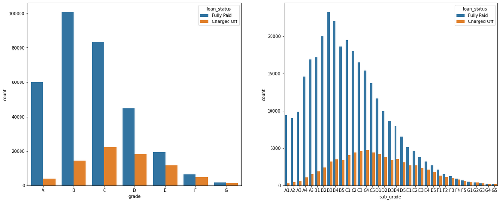

```python
plt.figure(figsize=(20, 8))

plt.subplot(1, 2, 1)
sns.countplot(x = df['grade'], hue=df['loan_status'], order = sorted(df['grade'].unique().tolist()))

plt.subplot(1, 2, 2)
sns.countplot(x = df['sub_grade'], hue=df['loan_status'], order = sorted(df['sub_grade'].unique().tolist()))
plt.show()
```

Insights:-

1. Grade A, B, C and D are grades where fully-paid applicants are twice of defaulters.
2. Out of above grades, grade B applicants are maximum that paid the loan fully.

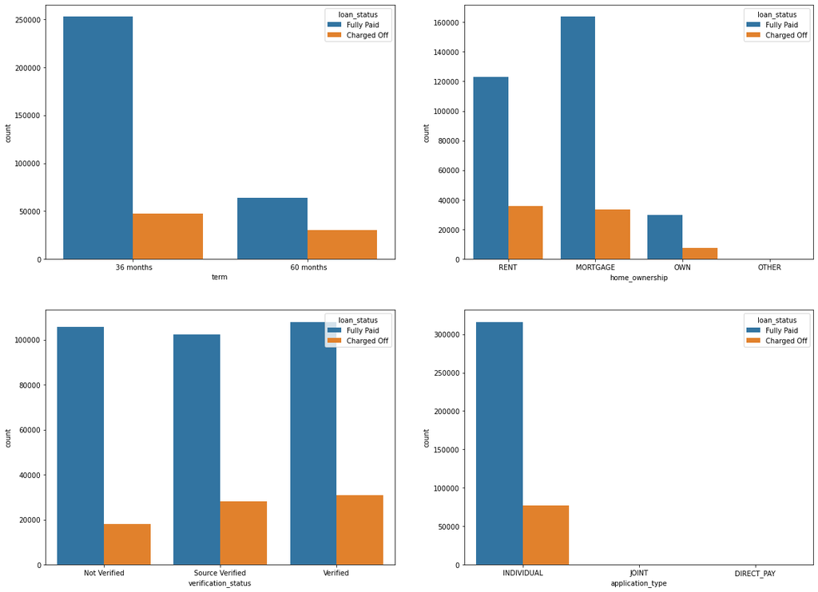

```python
plt.figure(figsize=(20, 15))

plt.subplot(2, 2, 1)
sns.countplot(x=df['term'], hue=df['loan_status'])

plt.subplot(2, 2, 2)
sns.countplot(x=df['home_ownership'], hue=df['loan_status'])

plt.subplot(2, 2, 3)
sns.countplot(x=df['verification_status'], hue=df['loan_status'])

plt.subplot(2, 2, 4)
sns.countplot(x=df['application_type'], hue=df['loan_status'])

plt.show()
```

Insights:-

1. 36 months period is opted by most of the applicants.
2. 36 months tenure loan has high success rate (fully paid rate) than 60 months rate.
3. Most of the applicants report their home-ownership as 'Mortgage' or 'Rent'.
4. Individual Applicants generally applied for the loan.

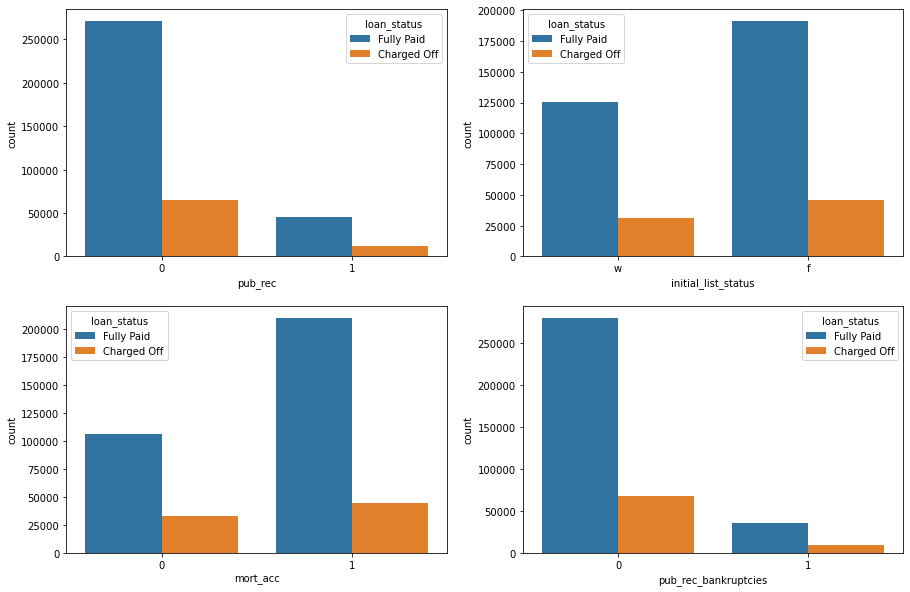

```python
plt.figure(figsize=(15, 10))

plt.subplot(2, 2, 1)
sns.countplot(x=df['pub_rec'], hue=df['loan_status'])

plt.subplot(2, 2, 2)
sns.countplot(x=df['initial_list_status'], hue=df['loan_status'])

plt.subplot(2, 2, 3)
sns.countplot(x=df['mort_acc'], hue=df['loan_status'])

plt.subplot(2, 2, 4)
sns.countplot(x=df['pub_rec_bankruptcies'], hue=df['loan_status'])

plt.show()
```

Insights:-

1. Applicants with no derogatory remarks have high chance of getting loan and higher success of paying the loan back.
2. fractional loan status count is slightly high compared to whole loan status.
3. Applicants with mortgage accounts have high chance of getting loan and higher success of paying the loan back.
4. Applicants with no bankruptcies have high chance of getting loan and higher success of paying the loan back.

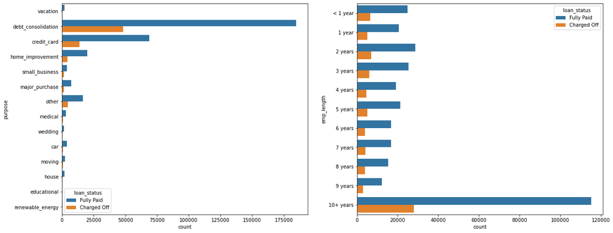

```python
plt.figure(figsize = (20, 8))

plt.subplot(1, 2, 1)
sns.countplot(y = df['purpose'], hue = df['loan_status'])


plt.subplot(1, 2, 2)
order = ['< 1 year', '1 year', '2 years', '3 years', '4 years', '5 years', '6 years', '7 years', '8 years', '9 years', '10+ years']
sns.countplot(y = df['emp_length'], hue = df['loan_status'], order = order)

plt.show()
```

Insights:-

1. Debt consolidation and credit card are the major purpose to be reported in loan application.
2. Applicants with larger length of employment has high chance of getting a loan.

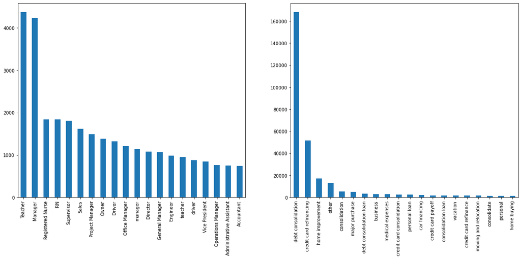

```python
plt.figure(figsize = (20, 8))

plt.subplot(1, 2, 1)
df['emp_title'].value_counts()[1:21].plot(kind='bar')

plt.subplot(1, 2, 2)
df['title'].value_counts()[:20].plot(kind='bar')
```

Insights:-

1. Teacher and Manager are occupation with highest chance of getting the loan.

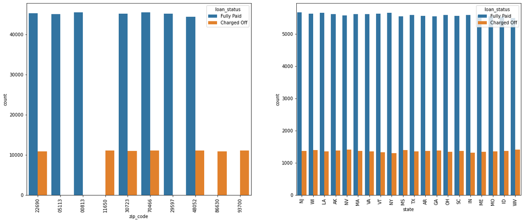

```python
plt.figure(figsize = (20, 8))

plt.subplot(1, 2, 1)
sns.countplot(x = df['zip_code'], hue = df['loan_status'])
plt.xticks(rotation = 90)

plt.subplot(1, 2, 2)
top_20_states = df['state'].value_counts()[1:21].index
df_top_20 = df.loc[df['state'].isin(top_20_states)]
sns.countplot(x = df_top_20['state'], hue=df_top_20['loan_status'], order=top_20_states)
plt.xticks(rotation = 90)

plt.show()
```

Insights:-

1. Zip-code: 05113, 00813, 29597 are the areas where almost every applicant has paid their loan successfully.
2. Zip-code 11650, 86630, 93700 are the areas where almost every applicant has defaulted.

### Co-relation Matrix and Heatmaps

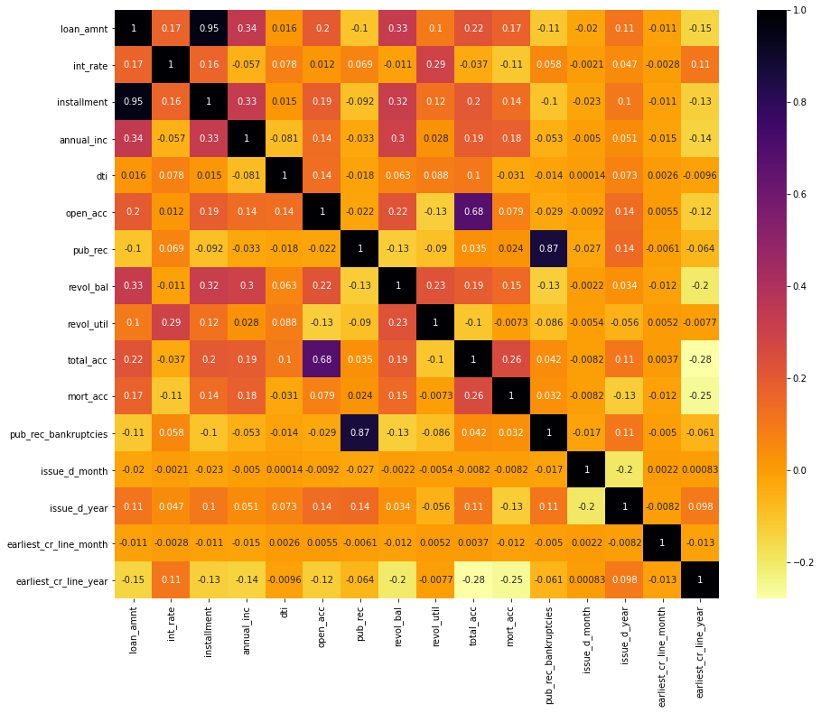

```python
plt.figure(figsize=(15, 12))
sns.heatmap(df.corr(method="pearson"), annot = True, cmap = "inferno_r")
plt.show()
```

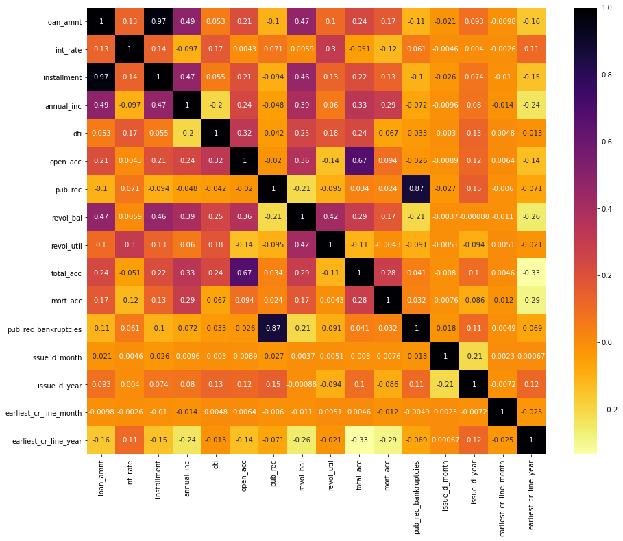

```python
plt.figure(figsize=(15, 12))
sns.heatmap(df.corr(method="spearman"), annot = True, cmap = "inferno_r")
plt.show()
```

- (loan_amnt, installment), (pub_rec_bankruptcies, pub_rec) pairs are highly co-related.
- Hence dropping installment and pub_rec_bankruptcies.

```python
df.drop(columns=['installment', 'pub_rec_bankruptcies'], inplace=True)
```

### Outliers Detection using histogram and their treatment

```python
num_cols = df.select_dtypes(include='number').columns
num_cols
```

```
Index(['loan_amnt', 'int_rate', 'annual_inc', 'dti', 'open_acc', 'pub_rec',
       'revol_bal', 'revol_util', 'total_acc', 'mort_acc', 'issue_d_month',
       'issue_d_year', 'earliest_cr_line_month', 'earliest_cr_line_year'],
      dtype='object')
```

```python
def show_box_plot(feature: str) -> None:
    plt.figure(figsize=(12, 6))
    sns.boxplot(x = df[feature])
    plt.title(f'Box-Plot of {feature}')
    plt.show()
```

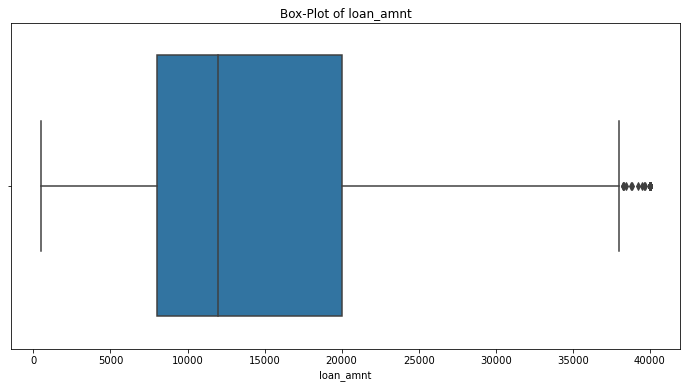

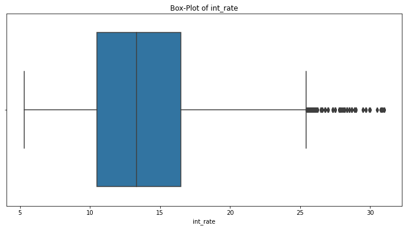

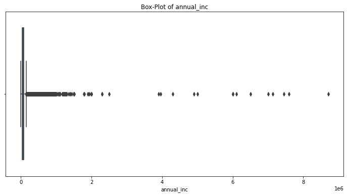

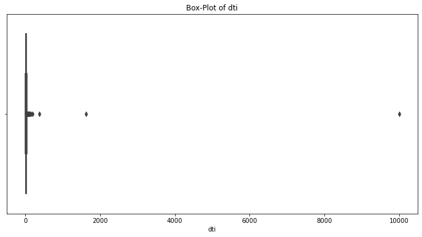

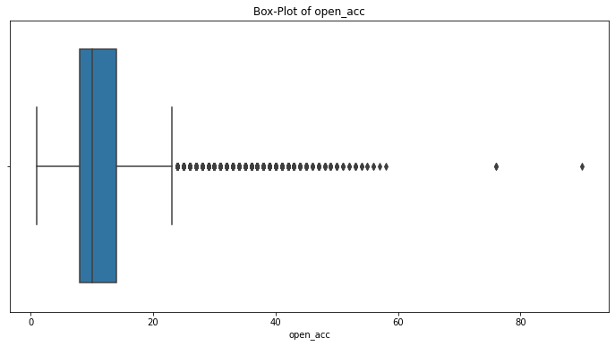

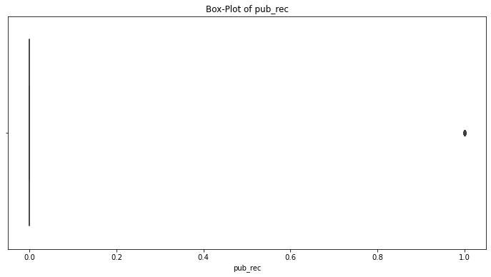

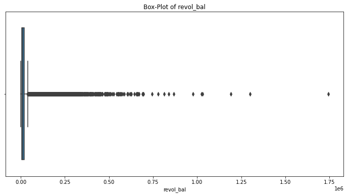

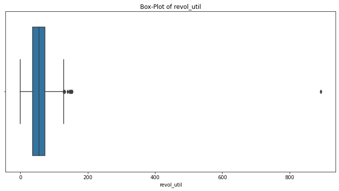

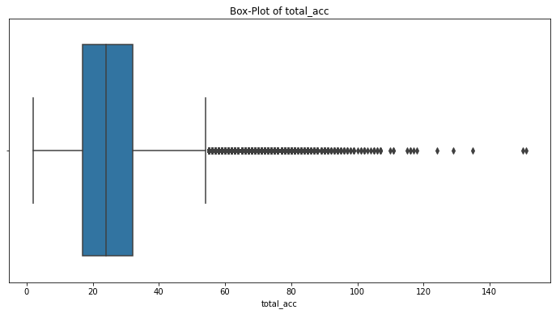

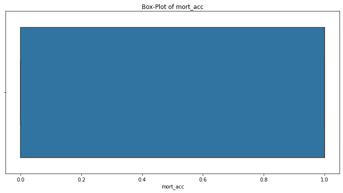

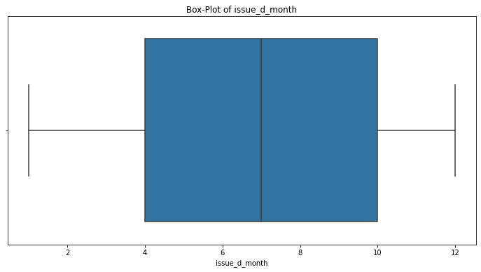

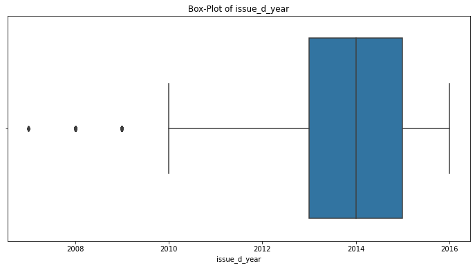

[2 more figures not shown]

```python
for feature in num_cols:
    show_box_plot(feature)
```

- Boxplots have shown lot of outliers,
- let's treat them using z-score trimming method.

```python
for feature in num_cols:
    mean = df[feature].mean()
    std_dev = df[feature].std()

    lower_limit = mean - 3*std_dev
    upper_limit = mean + 3*std_dev

    df = df[ (df[feature] > lower_limit) & (df[feature] < upper_limit) ]
```

```python
df.shape
```

```
(367495, 28)
```

## Encoding

### Label Encoding

```python
# 'term' column cleaning
term_mapping ={
    ' 36 months': 36,
    ' 60 months': 60
}

df['term'] = df['term'].map(term_mapping)
df['term'].unique()
```

```
array([36, 60], dtype=int64)
```

```python
# 'grade' column encoding
grade_mapping = {'A': 1, 'B': 2, 'C': 3, 'D': 4, 'E': 5, 'F': 6, 'G': 7}

df['grade'] = df['grade'].map(grade_mapping)
df['grade'].unique()
```

```
array([2, 1, 3, 5, 4, 6, 7], dtype=int64)
```

```python
# 'sub_grade' column encoding
# encoding A1, B1, C1, ... -> 1 (because grade feature will take care of grades)
sub_grade_mapping = {ele: int(ele[1]) for ele in df['sub_grade'].values}

df['sub_grade'] = df['sub_grade'].map(sub_grade_mapping)
df['sub_grade'].unique()
```

```
array([4, 5, 3, 2, 1], dtype=int64)
```

```python
# 'emp_length' column cleaning
emp_length_mapping = {
    '10+ years': 10, '4 years': 4, '< 1 year': 0, '6 years': 6, '9 years': 9,
    '2 years': 2, '3 years': 3, '8 years': 8, '7 years': 7, '5 years': 5, '1 year': 1
}

df['emp_length'] = df['emp_length'].map(emp_length_mapping)
df['emp_length'].unique()
```

```
array([10,  4,  0,  6,  9,  2,  3,  7,  8,  5,  1], dtype=int64)
```

Mapping of Target Feature

```python
# loan_status column encoding
# loan_status is the target variable
loan_status_mapping = {'Fully Paid': 0, 'Charged Off': 1}

df['loan_status'] = df['loan_status'].map(loan_status_mapping)
df['loan_status'].unique()
```

```
array([0, 1], dtype=int64)
```

Mapping of initial_list_status feature

- It contains 2 unique values so Label Encoding is a good choice.

```python
df['initial_list_status'].unique()
```

```
array(['w', 'f'], dtype=object)
```

```python
df['initial_list_status'] = df['initial_list_status'].map({'w': 0, 'f': 1})
df['initial_list_status'].unique()
```

```
array([0, 1], dtype=int64)
```

### One-hot Encoding

```python
df.select_dtypes(include="object").nunique()
```

```
emp_title              162992
home_ownership              4
verification_status         3
purpose                    14
title                   37131
application_type            3
state                      52
zip_code                   10
dtype: int64
```

- emp_title, title, state contains lots of unique values, so I am dropping them to avoid curse of dimensionality.

```python
df.drop(['emp_title', 'title', 'state'], axis=1, inplace=True)
```

Performing one-hot encoding now for other features

```python
dummies = ['purpose', 'zip_code', 'verification_status', 'application_type', 'home_ownership']
df = pd.get_dummies(df, columns=dummies, drop_first=True)
```

```python
df.head()
```

|  | loan_amnt | term | int_rate | grade | sub_grade | emp_length | annual_inc | loan_status | dti | open_acc | ... | zip_code_70466 | zip_code_86630 | zip_code_93700 | verification_status_Source Verified | verification_status_Verified | application_type_INDIVIDUAL | application_type_JOINT | home_ownership_OTHER | home_ownership_OWN | home_ownership_RENT |
| --- | --- | --- | --- | --- | --- | --- | --- | --- | --- | --- | --- | --- | --- | --- | --- | --- | --- | --- | --- | --- | --- |
| 0 | 10000.0 | 36 | 11.44 | 2 | 4 | 10 | 117000.0 | 0 | 26.24 | 16.0 | ... | 0 | 0 | 0 | 0 | 0 | 1 | 0 | 0 | 0 | 1 |
| 1 | 8000.0 | 36 | 11.99 | 2 | 5 | 4 | 65000.0 | 0 | 22.05 | 17.0 | ... | 0 | 0 | 0 | 0 | 0 | 1 | 0 | 0 | 0 | 0 |
| 2 | 15600.0 | 36 | 10.49 | 2 | 3 | 0 | 43057.0 | 0 | 12.79 | 13.0 | ... | 0 | 0 | 0 | 1 | 0 | 1 | 0 | 0 | 0 | 1 |
| 3 | 7200.0 | 36 | 6.49 | 1 | 2 | 6 | 54000.0 | 0 | 2.60 | 6.0 | ... | 0 | 0 | 0 | 0 | 0 | 1 | 0 | 0 | 0 | 1 |
| 4 | 24375.0 | 60 | 17.27 | 3 | 5 | 9 | 55000.0 | 1 | 33.95 | 13.0 | ... | 0 | 0 | 0 | 0 | 1 | 1 | 0 | 0 | 0 | 0 |

5 rows × 49 columns

## Saving the data to a file

```python
df.to_csv("loan_tap_clean.csv", index=False)
```

# Building Classification Model

```python
df = pd.read_csv('loan_tap_clean.csv')
df.head()
```

|  | loan_amnt | term | int_rate | grade | sub_grade | emp_length | annual_inc | loan_status | dti | open_acc | ... | zip_code_70466 | zip_code_86630 | zip_code_93700 | verification_status_Source Verified | verification_status_Verified | application_type_INDIVIDUAL | application_type_JOINT | home_ownership_OTHER | home_ownership_OWN | home_ownership_RENT |
| --- | --- | --- | --- | --- | --- | --- | --- | --- | --- | --- | --- | --- | --- | --- | --- | --- | --- | --- | --- | --- | --- |
| 0 | 10000.0 | 36 | 11.44 | 2 | 4 | 10 | 117000.0 | 0 | 26.24 | 16.0 | ... | 0 | 0 | 0 | 0 | 0 | 1 | 0 | 0 | 0 | 1 |
| 1 | 8000.0 | 36 | 11.99 | 2 | 5 | 4 | 65000.0 | 0 | 22.05 | 17.0 | ... | 0 | 0 | 0 | 0 | 0 | 1 | 0 | 0 | 0 | 0 |
| 2 | 15600.0 | 36 | 10.49 | 2 | 3 | 0 | 43057.0 | 0 | 12.79 | 13.0 | ... | 0 | 0 | 0 | 1 | 0 | 1 | 0 | 0 | 0 | 1 |
| 3 | 7200.0 | 36 | 6.49 | 1 | 2 | 6 | 54000.0 | 0 | 2.60 | 6.0 | ... | 0 | 0 | 0 | 0 | 0 | 1 | 0 | 0 | 0 | 1 |
| 4 | 24375.0 | 60 | 17.27 | 3 | 5 | 9 | 55000.0 | 1 | 33.95 | 13.0 | ... | 0 | 0 | 0 | 0 | 1 | 1 | 0 | 0 | 0 | 0 |

5 rows × 49 columns

## Utility functions

```python
def show_roc_curve(y_true, y_pred_proba):
    fpr, tpr, thresholds = metrics.roc_curve(y_true, y_pred_proba)
    roc_area_score = metrics.auc(fpr, tpr)

    plt.figure(figsize=(8, 6))

    plt.plot(fpr, tpr, label = f'Logistic Regression (ROC Area Score: {round(roc_area_score, 2)})')
    plt.plot(fpr, fpr, 'r--', label = "Random Model (ROC Area Score: 0.5)")

    # Axis labels
    plt.xlabel("False Positive rate")
    plt.ylabel("True Positive Rate")

    # Other properties
    plt.grid()
    plt.title("ROC curve")
    plt.legend(loc = "lower right")

    plt.show()
```

```python
def show_pr_curve(y_true, y_pred_proba):
    precisions, recalls, thresholds = metrics.precision_recall_curve(y_true, y_pred_proba)
    pr_area_score = metrics.auc(recalls, precisions)

    plt.figure(figsize=(8, 6))

    plt.plot(recalls, precisions, label = f'Logistic Regression (PR score: {round(pr_area_score, 2)})')
    plt.plot(recalls, 1 - recalls, 'r--', label = "Random Model (ROC score: 0.5)")

    # Axis labels
    plt.xlabel("Recalls")
    plt.ylabel("Precisions")

    # Other properties
    plt.title("PR curve")
    plt.legend(loc = "lower left")
    plt.grid()

    plt.show()
```

```python
def show_pr_trade_off_curve(y_true, y_pred_proba):
    precisions, recalls, thresholds = metrics.precision_recall_curve(y_true, y_pred_proba)
    boundary = thresholds.shape[0]

    plt.figure(figsize=(8, 6))

    # precision plot
    plt.plot(thresholds, precisions[:boundary], 'b--', label = 'precision')

    # recall plot
    plt.plot(thresholds, recalls[:boundary], 'r--', label = 'recall')

    # Axis labels
    plt.xlabel("Threshold")
    plt.xlabel("Precision/Recall")

    # Other properties
    plt.legend()
    plt.grid()
    plt.title('Precision-Recall Trade off')

    plt.show()
```

```python
def show_metrics_summary(y_true, y_pred, y_pred_proba):
    print(metrics.classification_report(y_true, y_pred))
    print('---------------------------------------------------------------------------------------')

    cm = metrics.confusion_matrix(y_true, y_pred)
    print(cm)
    print('---------------------------------------------------------------------------------------')
    print(cm*100/cm.sum())
    print('---------------------------------------------------------------------------------------')

    metrics.ConfusionMatrixDisplay(cm).plot()
    plt.show()

    show_roc_curve(y_true, y_pred_proba)
    show_pr_curve(y_true, y_pred_proba)
    show_pr_trade_off_curve(y_true, y_pred_proba)
```

## Logistic Regression Model -1

- without class balancing, regularizer and multi-collinearity check

**X and y**

```python
X = df.drop('loan_status', axis=1)
y = df['loan_status']
```

**train-test split**

```python
X_train, X_test, y_train, y_test = train_test_split(X, y, random_state=10, test_size=0.4)

print(X_train.shape)
print(X_test.shape)
```

```
(220497, 48)
(146998, 48)
```

**Scaling**

```python
scaler = MinMaxScaler()

X_train = scaler.fit_transform(X_train)
X_test = scaler.transform(X_test)
```

**Classification Model**

```python
model = LogisticRegression(max_iter=1000)  # Adjust iterations based on need

model.fit(X_train, y_train)
```

```
LogisticRegression(max_iter=1000)
```

**Model Performace**

```python
y_pred = model.predict(X_test)
y_pred_proba = model.predict_proba(X_test)[:, 1]
```

```
              precision    recall  f1-score   support

           0       0.89      0.99      0.93    117931
           1       0.91      0.48      0.63     29067

    accuracy                           0.89    146998
   macro avg       0.90      0.73      0.78    146998
weighted avg       0.89      0.89      0.87    146998

---------------------------------------------------------------------------------------
[[116581   1350]
 [ 15082  13985]]
---------------------------------------------------------------------------------------
[[79.30788174  0.91837984]
 [10.26000354  9.51373488]]
---------------------------------------------------------------------------------------
```

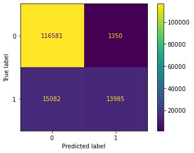

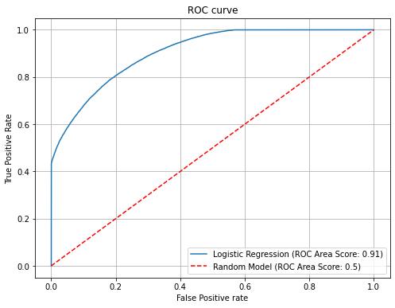

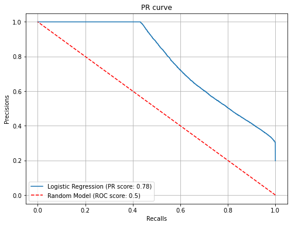

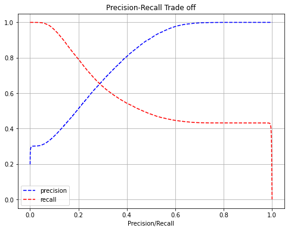

```python
show_metrics_summary(y_test, y_pred, y_pred_proba)
```

```python
metrics.fbeta_score(y_test, y_pred, beta=2)
```

```
0.5313328723509343
```

Insights:-

1. Metrics summary of Logistic Regression without handling balancing, regularization and multi-collinearity check:
   - Accuracy: 0.89
   - Precision: 0.91
   - Recall: 0.48
   - F1-score: 0.63
   - ROC-AUC: 0.91
   - PR-AUC: 0.78
   - fbeta(beta=2): 0.53
2. Confusion Matrix:
   - TN: 79.3%
   - FP: 0.91%
   - FN: 10.26%
   - TP: 9.51%

## Multi-Collinearity check and its removal

```python
X = df.drop('loan_status', axis=1)
y = df['loan_status']
```

```python
def remove_features_by_vif(X: pd.DataFrame, vif_threshold = 10):
    features = X.columns.to_list()
    dropped_features = list()

    while True:
        # calculate vifs
        vifs = [variance_inflation_factor(X.values, i) for i in range(X.shape[1])]
        vifs = list(zip(features, vifs))

        # sort vifs
        vifs.sort(key= lambda x: x[1], reverse=True)

        # top vif
        top_vif = vifs[0][1]
        top_vif_feature = vifs[0][0]

        if top_vif < vif_threshold:
            break

        # drop top vif feature
        dropped_features.append(top_vif_feature)
        X.drop(columns=[top_vif_feature], inplace=True)
        features.remove(top_vif_feature)

    return dropped_features
```

```python
dropped_features = remove_features_by_vif(X, vif_threshold= 10)
dropped_features
```

```
['issue_d_year',
 'earliest_cr_line_year',
 'int_rate',
 'application_type_INDIVIDUAL',
 'term',
 'purpose_debt_consolidation',
 'open_acc']
```

### Logistic Regression after removal of multi-collinearity

**train-test split**

```python
X_train, X_test, y_train, y_test = train_test_split(X, y, random_state=10, test_size=0.4)

print(X_train.shape)
print(X_test.shape)
```

```
(220497, 41)
(146998, 41)
```

**Scaling**

```python
scaler = MinMaxScaler()

X_train = scaler.fit_transform(X_train)
X_test = scaler.transform(X_test)
```

**Classification Model**

```python
model = LogisticRegression(max_iter=1000)  # Adjust iterations based on need

model.fit(X_train, y_train)
```

```
LogisticRegression(max_iter=1000)
```

**Model Performace**

```python
y_pred = model.predict(X_test)
y_pred_proba = model.predict_proba(X_test)[:, 1]
```

```
              precision    recall  f1-score   support

           0       0.88      0.99      0.93    117931
           1       0.93      0.47      0.63     29067

    accuracy                           0.89    146998
   macro avg       0.90      0.73      0.78    146998
weighted avg       0.89      0.89      0.87    146998

---------------------------------------------------------------------------------------
[[116820   1111]
 [ 15335  13732]]
---------------------------------------------------------------------------------------
[[79.47046899  0.7557926 ]
 [10.43211472  9.3416237 ]]
---------------------------------------------------------------------------------------
```

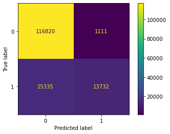

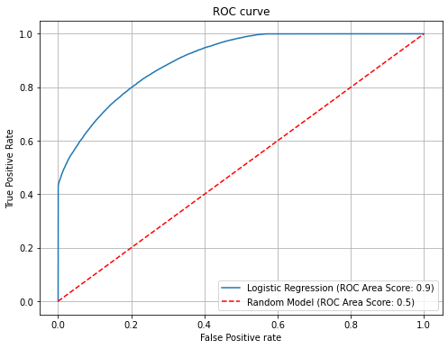

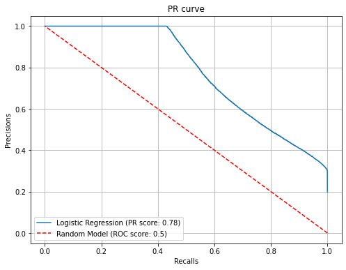

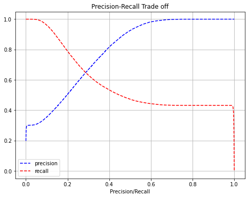

```python
show_metrics_summary(y_test, y_pred, y_pred_proba)
```

```python
metrics.fbeta_score(y_test, y_pred, beta=2)
```

```
0.5236784098969576
```

Insights:-

1. Metrics summary of Logistic Regression after multi-collinearity check:
   - Accuracy: 0.89
   - Precision: 0.93
   - Recall: 0.47
   - F1-score: 0.63
   - ROC-AUC: 0.9
   - PR-AUC: 0.78
   - fbeta(beta=2): 0.52
2. Confusion Matrix:
   - TN: 79.47%
   - FP: 0.75%
   - FN: 10.43%
   - TP: 9.34%

## Handling Imbalance using class-weights

**X and y**

```python
X = df.drop('loan_status', axis=1)
y = df['loan_status']
```

**Drop non-important features**

```python
X.drop(columns=dropped_features, inplace=True)
```

**train-test split**

```python
X_train, X_test, y_train, y_test = train_test_split(X, y, random_state=10, test_size=0.4)

print(X_train.shape)
print(X_test.shape)
```

```
(220497, 41)
(146998, 41)
```

**Scaling**

```python
scaler = MinMaxScaler()

X_train = scaler.fit_transform(X_train)
X_test = scaler.transform(X_test)
```

**Classification Model**

```python
model = LogisticRegression(max_iter=1000, class_weight='balanced')  # Adjust iterations based on need

model.fit(X_train, y_train)
```

```
LogisticRegression(class_weight='balanced', max_iter=1000)
```

**Model Performace**

```python
y_pred = model.predict(X_test)
y_pred_proba = model.predict_proba(X_test)[:, 1]
```

```
              precision    recall  f1-score   support

           0       0.94      0.81      0.87    117931
           1       0.50      0.79      0.61     29067

    accuracy                           0.80    146998
   macro avg       0.72      0.80      0.74    146998
weighted avg       0.85      0.80      0.82    146998

---------------------------------------------------------------------------------------
[[94950 22981]
 [ 6021 23046]]
---------------------------------------------------------------------------------------
[[64.59271555 15.63354603]
 [ 4.09597409 15.67776432]]
---------------------------------------------------------------------------------------
```

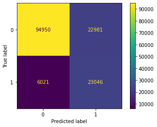

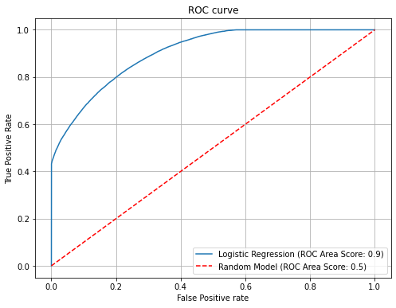

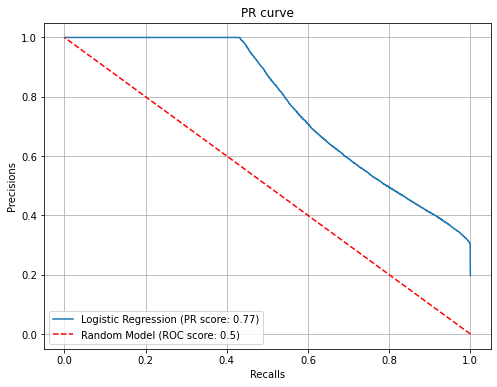

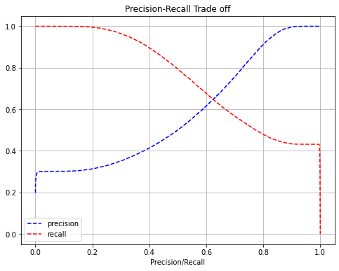

```python
show_metrics_summary(y_test, y_pred, y_pred_proba)
```

```python
metrics.fbeta_score(y_test, y_pred, beta=2)
```

```
0.7100033888906004
```

Insights:-

1. Metrics summary of Logistic Regression after handling balancing and multi-collinearity check:
   - Accuracy: 0.8
   - Precision: 0.5
   - Recall: 0.79
   - F1-score: 0.61
   - ROC-AUC: 0.9
   - PR-AUC: 0.77
   - fbeta(beta=2): 0.71
2. Confusion Matrix:
   - TN: 64.59%
   - FP: 15.63%
   - FN: 4.09%
   - TP: 15.67%

## Regularization (L2 regularizer) and Cross Validation

**X and y**

```python
X = df.drop('loan_status', axis=1)
y = df['loan_status']
```

**Drop non-important features**

```python
X.drop(columns=dropped_features, inplace=True)
```

**train-val-test split**

```python
X_train, X_test, y_train, y_test = train_test_split(X, y, random_state=10, test_size=1/4)
X_train, X_val, y_train, y_val = train_test_split(X_train, y_train, random_state=10, test_size=1/3)

print(X_train.shape)
print(X_val.shape)
print(X_test.shape)
```

```
(183747, 41)
(91874, 41)
(91874, 41)
```

**scaling**

```python
scaler = MinMaxScaler()

X_train = scaler.fit_transform(X_train)
X_val = scaler.transform(X_val)
X_test = scaler.transform(X_test)
```

**cross-validation**

```python
lamdas = [0.01, 0.1, 1, 10]
train_scores = list()
val_scores = list()

for lamda in lamdas:
    model = LogisticRegression(max_iter=1000, class_weight='balanced', penalty='l2', C= 1/lamda)

    # train the model
    model.fit(X_train, y_train)

    # training score
    y_train_pred = model.predict(X_train)
    train_scores.append(metrics.recall_score(y_train, y_train_pred))

    # validation score
    y_val_pred = model.predict(X_val)
    val_scores.append(metrics.recall_score(y_val, y_val_pred))

print(lamdas)
print(train_scores)
print(val_scores)
```

```
[0.01, 0.1, 1, 10]
[0.7946626719928983, 0.7946071904127829, 0.794329782512206, 0.7925821127385708]
[0.7881546476556074, 0.7881546476556074, 0.7878256100904854, 0.7863997806416233]
```

- Not much difference in using different lambdas
- let use lambda = 0.01

### Test score/summary

**Classification Model**

```python
model = LogisticRegression(max_iter=1000, class_weight='balanced', penalty='l2', C= 1/0.01)  # Adjust iterations based on need

model.fit(X_train, y_train)
```

```
LogisticRegression(C=100.0, class_weight='balanced', max_iter=1000)
```

**Model Performace**

```python
y_pred = model.predict(X_test)
y_pred_proba = model.predict_proba(X_test)[:, 1]
```

```
              precision    recall  f1-score   support

           0       0.94      0.81      0.87     73683
           1       0.50      0.79      0.62     18191

    accuracy                           0.80     91874
   macro avg       0.72      0.80      0.74     91874
weighted avg       0.85      0.80      0.82     91874

---------------------------------------------------------------------------------------
[[59553 14130]
 [ 3833 14358]]
---------------------------------------------------------------------------------------
[[64.82029736 15.37975924]
 [ 4.1720182  15.6279252 ]]
---------------------------------------------------------------------------------------
```

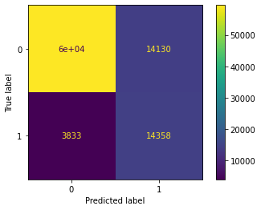

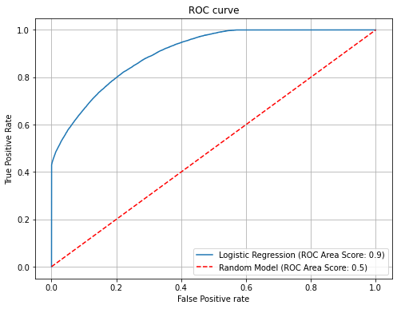

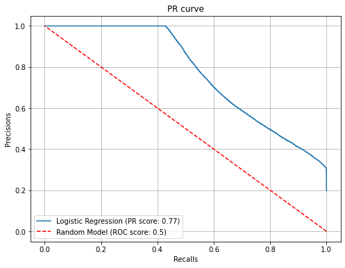

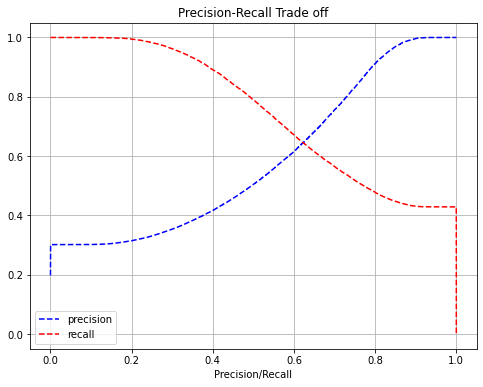

```python
show_metrics_summary(y_test, y_pred, y_pred_proba)
```

```python
metrics.fbeta_score(y_test, y_pred, beta=2)
```

```
0.7090230316438193
```

Insights:-

1. Metrics summary of Logistic Regression after handling balancing, multi-collinearity check, cross-validation and regularization:
   - Accuracy: 0.8
   - Precision: 0.5
   - Recall: 0.79
   - F1-score: 0.62
   - ROC-AUC: 0.9
   - PR-AUC: 0.77
   - fbeta(beta=2): 0.71
2. Confusion Matrix:
   - TN: 64.82%
   - FP: 15.37%
   - FN: 4.17%
   - TP: 15.62%

## Logistic Regression Model - (final)

**X and y**

```python
X = df.drop('loan_status', axis=1)
y = df['loan_status']
```

**Drop non-important features**

```python
X.drop(columns=dropped_features, inplace=True)
```

**train-test split**

```python
X_train, X_test, y_train, y_test = train_test_split(X, y, random_state=10, test_size=0.4)

print(X_train.shape)
print(X_test.shape)
```

```
(220497, 41)
(146998, 41)
```

**Scaling**

```python
scaler = MinMaxScaler()

X_train = scaler.fit_transform(X_train)
X_test = scaler.transform(X_test)
```

**Classification Model**

```python
model = LogisticRegression(max_iter=1000, class_weight='balanced', penalty='l2', C=1/0.01)  # Adjust iterations based on need

model.fit(X_train, y_train)
```

```
LogisticRegression(C=100.0, class_weight='balanced', max_iter=1000)
```

**Model Performace**

```python
y_pred = model.predict(X_test)
y_pred_proba = model.predict_proba(X_test)[:, 1]
```

```
              precision    recall  f1-score   support

           0       0.94      0.80      0.87    117931
           1       0.50      0.79      0.61     29067

    accuracy                           0.80    146998
   macro avg       0.72      0.80      0.74    146998
weighted avg       0.85      0.80      0.82    146998

---------------------------------------------------------------------------------------
[[94928 23003]
 [ 6019 23048]]
---------------------------------------------------------------------------------------
[[64.57774936 15.64851222]
 [ 4.09461353 15.67912489]]
---------------------------------------------------------------------------------------
```

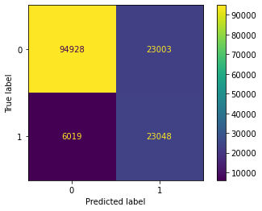

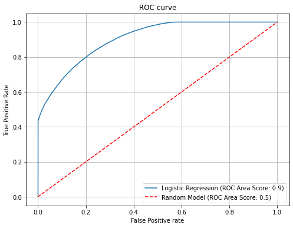

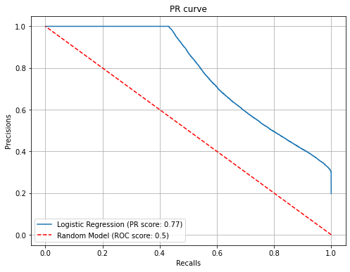

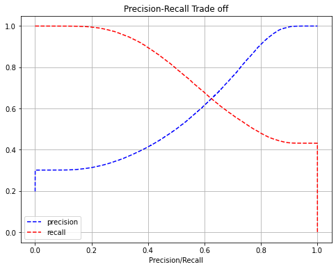

```python
show_metrics_summary(y_test, y_pred, y_pred_proba)
```

```python
metrics.fbeta_score(y_test, y_pred, beta=2)
```

```
0.7099600170035547
```

**comparing weights**

```python
feature_with_weights = list(zip(X.columns, model.coef_.flatten().tolist()))
feature_with_weights.sort(key=lambda x: x[1], reverse=True)

feature_with_weights[:10]
```

```
[('zip_code_93700', 20.507644059351133),
 ('zip_code_11650', 20.49416052939432),
 ('zip_code_86630', 20.35131438231251),
 ('zip_code_48052', 9.785400878146039),
 ('zip_code_70466', 9.753018661142576),
 ('zip_code_30723', 9.747578592989196),
 ('zip_code_22690', 9.734376695171463),
 ('grade', 2.6427442289162046),
 ('dti', 1.7199235354775095),
 ('loan_amnt', 0.7445231314973701)]
```

Insights:-

1. Metrics summary of my final Logistic Regression model:
   - Accuracy: 0.8
   - Precision: 0.5
   - Recall: 0.79
   - F1-score: 0.61
   - ROC-AUC: 0.9
   - PR-AUC: 0.77
   - fbeta(beta=2): 0.71
2. Confusion Matrix:
   - TN: 64.57%
   - FP: 15.64%
   - FN: 4.09%
   - TP: 15.67%
3. Zip-code (address), grade, dti and loan_amnt are the most important features by weights.

# Conclusion

## Summarizing Insights

### **Exploratory Data Analysis (EDA) Insights:**

- **Dataset Overview:**
  - Total Rows: 396,030
  - Total Columns: 27
  - No duplicates; some missing values were noted.
- **Grade and Repayment:**
  - Grades A, B, C, and D have a higher number of fully-paid applicants compared to defaulters.
  - Grade B has the highest count of fully-paid loans.
- **Loan Term Insights:**
  - The 36-month period is the most common choice among applicants.
  - Loans with a 36-month term have a higher success rate compared to 60-month loans.
- **Applicant Characteristics:**
  - Most applicants report home ownership as 'Mortgage' or 'Rent.'
  - Individual applicants are more likely to apply for loans.
  - Applicants with no derogatory remarks or bankruptcies, and those with mortgage accounts, have a higher chance of receiving loans and successfully repaying them.
- **Loan Purpose:**
  - Debt consolidation and credit card repayment are the most common reasons for applying.
  - Applicants with longer employment histories have a higher likelihood of loan approval.
- **Occupation and Location Insights:**
  - Teachers and Managers are the occupations most likely to be granted loans.
  - Certain ZIP codes (e.g., 05113, 00813) are associated with high loan repayment rates, while others (e.g., 11650, 86630) have high default rates.
- **Feature Correlations:**
  - Strong correlations were found between `(loan_amnt, installment)` and `(pub_rec_bankruptcies, pub_rec)`.

### **Logistic Regression Model Insights:**

- **Accuracy:** 0.8
- **Precision:** 0.5
- **Recall:** 0.79
- **F1-Score:** 0.61
- **ROC-AUC:** 0.9
- **PR-AUC:** 0.77
- **Confusion Matrix:** TN: 64.57%, FP: 15.64%, FN: 4.09%, TP: 15.67%
- **Key Features:** ZIP code, grade, debt-to-income ratio (DTI), and loan amount were identified as the most important features based on their weights.

## Some Questions

### **1. Comment on Final Model Statistics (including confusion matrix):**

The final logistic regression model demonstrates a balanced performance with a strong emphasis on recall. The key statistics are as follows:

- **Accuracy (0.8):** The model correctly predicts 80% of the cases, indicating a good overall performance.
- **Precision (0.5):** Precision is moderate, reflecting the trade-off between false positives and true positives. This indicates that while the model identifies a reasonable number of actual defaulters, it also misclassifies a notable proportion of non-defaulters as defaulters.
- **Recall (0.79):** The recall is high, which is crucial for minimizing false negatives—cases where a defaulter is incorrectly classified as a non-defaulter. This metric is particularly important in credit risk scenarios, where missing a defaulter can lead to significant financial losses.
- **F1-Score (0.61):** The F1-score balances precision and recall, providing a single metric to evaluate the model’s effectiveness. The score of 0.61 indicates a reasonable balance between the two.
- **ROC-AUC (0.9):** The high ROC-AUC value suggests that the model has a strong ability to distinguish between defaulters and non-defaulters.
- **PR-AUC (0.77):** The PR-AUC score further confirms the model's effectiveness in handling the imbalanced nature of the dataset.
- **Fbeta (0.71):** With a beta value of 2, the fbeta score prioritizes recall over precision, and a score of 0.71 reflects the model’s strength in correctly identifying defaulters.

The confusion matrix reveals a higher true negative rate (64.57%) compared to the true positive rate (15.67%), indicating the model is more conservative in predicting defaults. The false positive rate (15.64%) is slightly higher than desired, which suggests room for improvement in precision. However, the low false negative rate (4.09%) highlights the model's effectiveness in minimizing missed defaults, aligning with the business goal of reducing financial risk.

Overall, this model provides a robust framework for LoanTap to make informed lending decisions, balancing the need to identify high-risk applicants while minimizing potential losses.

### **2. ROC-AUC curve and its comment**

#### **Comment on ROC Curve**

- The ROC curve illustrates the True Positive Rate (TPR) against the False Positive Rate (FPR) for various threshold values.
- The area under the ROC curve (AUC) is 0.9, which signifies that the logistic regression model has a strong ability to differentiate between the positive (defaulter) and negative (non-defaulter) classes.

### **3. PR curve and its comment**

#### **Comment on PR Curve**

- The PR curve is particularly useful for evaluating model performance in cases of class imbalance.
- The area under the PR curve (PR AUC) is 0.77, indicating that the model effectively balances precision and recall.

#### **Comment on PR Trade-Off Curve**

- The PR trade-off curve illustrates the inverse relationship between precision and recall.
- As precision increases, recall typically decreases, and vice versa.
- The curve demonstrates that at various thresholds, the model can achieve either high precision with a trade-off in recall or high recall with a trade-off in precision.
- Understanding this trade-off is crucial for selecting the optimal threshold based on whether the priority is minimizing false positives (favoring precision) or minimizing false negatives (favoring recall).

### **4. How can we make sure that our model can detect real defaulters and there are less false positives? This is important as we can lose out on an opportunity to finance more individuals and earn interest on it.**

#### **Ensuring the Model Accurately Detects Real Defaulters and Minimizes False Positives**

To improve the detection of real defaulters while reducing false positives, several strategies can be employed:

1. **Adjust the Decision Threshold:**
   - The default threshold for classifying defaulters might be 0.5, but this can be adjusted to balance recall and precision. By lowering the threshold, the model can become more sensitive to potential defaulters, reducing false negatives. Conversely, raising the threshold can help minimize false positives.
2. **Incorporate More Granular Features:**
   - Consider adding or engineering features that provide more detailed insights into an applicant's financial behavior, such as credit utilization ratios, recent spending patterns, or more specific employment stability indicators. These can help the model differentiate between high-risk and low-risk applicants more effectively.
3. **Implement a Cost-Sensitive Learning Approach:**
   - Introduce a cost-sensitive learning framework where the cost of misclassifying a non-defaulter (false positive) is higher. This would encourage the model to be more cautious in predicting defaulters, reducing the number of false positives.
4. **Use Ensemble Methods:**
   - Combine multiple models, such as a random forest or gradient boosting, with logistic regression to leverage the strengths of each. Ensemble methods often provide better generalization and can reduce both false positives and false negatives.
5. **Apply More Rigorous Cross-Validation:**
   - Ensure that the model is tested across various subsets of the data through techniques like k-fold cross-validation. This helps in identifying any biases or inconsistencies in the model’s predictions, leading to a more reliable and accurate model.
6. **Regularly Update the Model with New Data:**
   - Continuously update the model with the latest data to ensure it captures recent trends and changes in borrower behavior. A model trained on outdated data might not perform well on new applicants, leading to higher false positives.
7. **Monitor and Fine-Tune the Model Post-Deployment:**
   - After deployment, keep track of the model’s performance metrics, especially the false positive rate. Fine-tune the model based on real-world data and outcomes to ensure it continues to meet the desired balance between detecting defaulters and minimizing false positives.
8. **Leverage Alternative Data Sources:**
   - Incorporate alternative data sources such as social media activity, digital footprints, or utility payment history. These can provide additional context that traditional credit metrics might miss, helping to refine the model’s predictions.
9. **Develop a Two-Stage Model:**
   - Consider implementing a two-stage model where the first stage identifies potential defaulters with high recall, and the second stage refines these predictions with a focus on minimizing false positives. This approach can help balance the competing objectives of recall and precision.
10. **Involve Human Review for Borderline Cases:**
    - For cases where the model’s prediction is uncertain or falls within a specific confidence range, involve human underwriters for final review. This can help catch errors that the model might make, particularly in borderline cases.

### **5. Since NPA (non-performing asset) is a real problem in this industry, it’s important we play safe and shouldn’t disburse loans to anyone. Comment on this.**

#### **Comment on Avoiding Risky Loan Disbursements Due to NPA Concerns**

Given the critical issue of Non-Performing Assets (NPA) in the lending industry, it is crucial to adopt a conservative approach when disbursing loans. NPAs can significantly impact a financial institution's profitability and liquidity, as they represent loans that borrowers are unlikely to repay. This makes it imperative to minimize exposure to high-risk applicants.

**Key Considerations:**

1. **Prioritize Conservative Risk Management:**
   - Given the financial implications of NPAs, the lending strategy should prioritize minimizing risk over maximizing loan disbursements. The cost of approving a high-risk applicant can outweigh the potential earnings from interest if the loan turns into an NPA.
2. **Rigorous Applicant Screening:**
   - Implementing stringent criteria for applicant evaluation is essential. By thoroughly analyzing applicants' credit histories, income stability, and other financial behaviors, the model can help identify and filter out high-risk applicants more effectively.
3. **Focus on Long-Term Stability:**
   - Disbursing loans to applicants with a proven track record of financial responsibility, even if it means rejecting a larger number of applications, will help ensure long-term financial stability. This approach helps prevent short-term gains from turning into long-term losses due to NPAs.
4. **Iterative Model Improvement:**
   - Continuously refine the predictive model based on emerging trends in borrower behavior and economic conditions. This will allow for better anticipation of potential defaults and reduce the likelihood of disbursing loans that could become NPAs.
5. **Balance Caution with Opportunity:**
   - While it is crucial to avoid disbursing loans to high-risk individuals, it’s also important not to be overly conservative. A balanced approach that includes regular updates to the model and consideration of new data sources can help identify safe lending opportunities without excessive risk.
6. **Regular Portfolio Monitoring:**
   - Continuously monitor the loan portfolio to identify early signs of potential defaults. Early intervention strategies can be developed to mitigate losses, thereby preventing loans from becoming NPAs.

**Conclusion:** In light of the NPA problem, playing it safe by being selective in loan disbursements is a prudent strategy. This approach helps protect the financial institution from potential losses while ensuring that the loans granted are more likely to be repaid.

## Questionnaire:

1. What percentage of customers have fully paid their Loan Amount?
   - **`80%`**
2. Comment about the correlation between Loan Amount and Installment features.
   - **High Co-relation: `0.97`**
3. The majority of people have home ownership as **___**.
   - **MORTGAGE**
4. People with grades ‘A’ are more likely to fully pay their loan. (T/F)
   - **True.** *Although grade B has highest applicants but grade A high loan payback rate.*
5. Name the top 2 afforded job titles.
   - **Teacher and Manager**
6. Thinking from a bank's perspective, which metric should our primary focus be on (ROC AUC, Precision, Recall, F1 Score)
   - In my opinion **Recall**. Because higher number of defaulters(False Negative) cause high financial loss.
   - But if Loan Tap is financially strong and wants to gain more interest than **F1-score** is also a good choice.
7. How does the gap in precision and recall affect the bank?
   - High Recall and Low Precision indicates lower number of Non-Performing Assest at the cost of gaining more interest.
   - Low Recall and High Precision indicates chance of gaining more interest at the cost of high number of Non-Performing Assest.
8. Which were the features that heavily affected the outcome?
   - **Address (Zip codes), Grade, DTI (debt-to-income ratio) and loan amount**
   - **Installment** is also a feature that heavily affected the outcome as it highly depends on Loan Amount.
9. Will the results be affected by geographical location? (Yes/No)
   - **Yes**
   - Zip-code: **`05113, 00813, 29597`** are the areas where almost every applicant has paid their loan successfully.
   - Zip-code **`11650, 86630, 93700`** are the areas where almost every applicant has defaulted.